# 1k_PBMC

alevinQC (v1.16.1)

2024-02-26

```r
## Read input files
if (!quiet) message("Reading Alevin-fry output files...")
alevin <- readAlevinFryQC(mapDir = mapDir, permitDir = permitDir,
                          quantDir = quantDir)
firstSelColName <- "inPermitList"
```

# Version info for alevin-fry run

```r
suppressWarnings({
    knitr::kable(
        alevin$versionTable
    )
})
```

| Start time | Mon Feb 26 14:13:41 2024 |
| --- | --- |
| Salmon version | 1.10.0 |
| alevin-fry version (quant) | 0.8.2 |
| Index | gencode.v45.annotation_splici_fl85_idx |
| R1file | pbmc_1k_v3_fastqs/pbmc_1k_v3_S1_L001_R1_001.fastq.gz, pbmc_1k_v3_fastqs/pbmc_1k_v3_S1_L002_R1_001.fastq.gz |
| R2file | pbmc_1k_v3_fastqs/pbmc_1k_v3_S1_L001_R2_001.fastq.gz, pbmc_1k_v3_fastqs/pbmc_1k_v3_S1_L002_R2_001.fastq.gz |
| tgMap | NA |
| Library type | ISR |

# Summary tables

## Full set of cell barcodes

```r
if (!quiet) message("Generating summary tables...")
suppressWarnings({
    knitr::kable(
        alevin$summaryTables$fullDataset
    )
})
```

| Total number of processed reads | 66601887 |
| --- | --- |
| Number of mapped reads | 59094345 |
| Total number of observed cell barcodes | 642051 |

## Permitlist

```r
suppressWarnings({
    knitr::kable(
        alevin$summaryTables$permitlist
    )
})
```

| Number of barcodes (permitlist) | 1152 |
| --- | --- |
| Number of barcodes with quantification (permitlist) | 1152 |
| Fraction mapped reads in barcodes (permitlist) | 93.22% |
| Mean number of mapped reads per cell (permitlist) | 44020 |
| Median number of mapped reads per cell (permitlist) | 38369 |
| Mean number of detected genes per cell (permitlist) | 4825 |
| Median number of detected genes per cell (permitlist) | 4464 |
| Mean UMI count per cell (permitlist) | 13448 |
| Median UMI count per cell (permitlist) | 11438 |

# Knee plot

The knee plot displays the number of times each cell barcode is observed, indecreasing order. By finding a ‘knee’ in this plot, alevin-fry determines a threshold (indicated in the plot) that defines a ‘permitlist’ - a set of cell barcodes that likely represent non-empty droplets - and distinguishes them from the background. In the figure below, red indicates cell barcodes in the permitlist, black indicates all other cell barcodes.

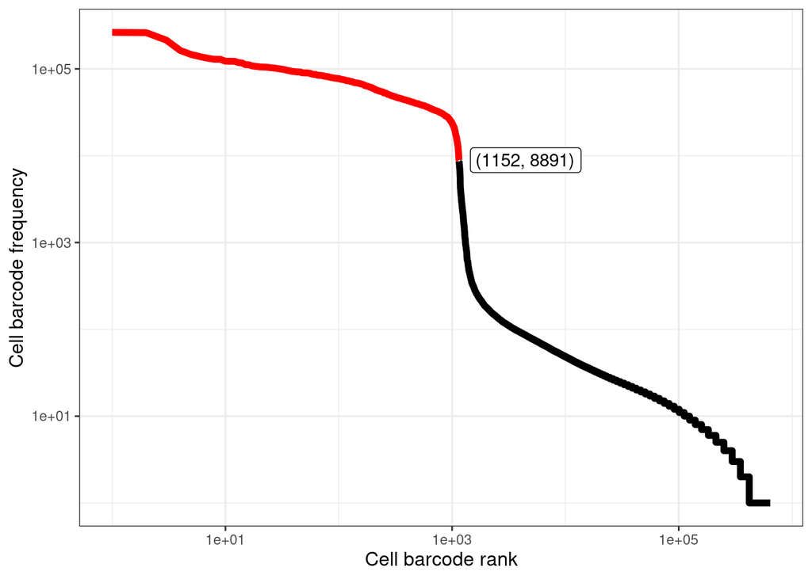

```r
if (!quiet) message("Generating knee plot...")
plotAlevinKneeRaw(alevin$cbTable, firstSelColName = firstSelColName)
```

# Cell barcode error correction and merging with initial whitelist

Once the initial permitlist of cell barcodes is defined, alevin-fry goes through the remaining cell barcodes. If a cell barcode is similar enough to cell barcode in the permitlist, it will be corrected and the reads will be added to those of the one in the permitlist. The figure below shows the original frequency of the barcodes in the permitlist vs the frequency after this correction. The reads corresponding to cell barcodes that can not be corrected to a barcode in the permitlist are discarded.

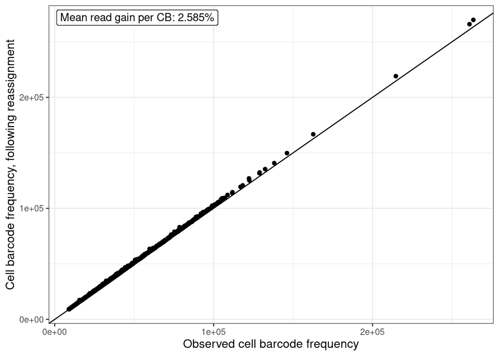

```r
if (!quiet) message("Generating barcode collapsing plot...")
plotAlevinBarcodeCollapse(alevin$cbTable, firstSelColName = firstSelColName,
                          countCol = "nbrMappedUMI")
```

# Quantification

After cell barcode collapsing, alevin-fry estimates the UMI count for each cell and gene. The plots below show the association between the cell barcode frequency (the number of observed reads corresponding to a cell barcode), the total UMI count and the number of detected genes.

These figures can give an indication of whether the sequenced reads actually align to genes, as well as the duplication rate and the degree of saturation. For many droplet data sets, the association between the barcode frequency and the total UMI count is rougly linear, while the association of any of these with the number of detected genes often deviates from linearity, if a small subset of the genes are assigned a large fraction of the UMI counts.

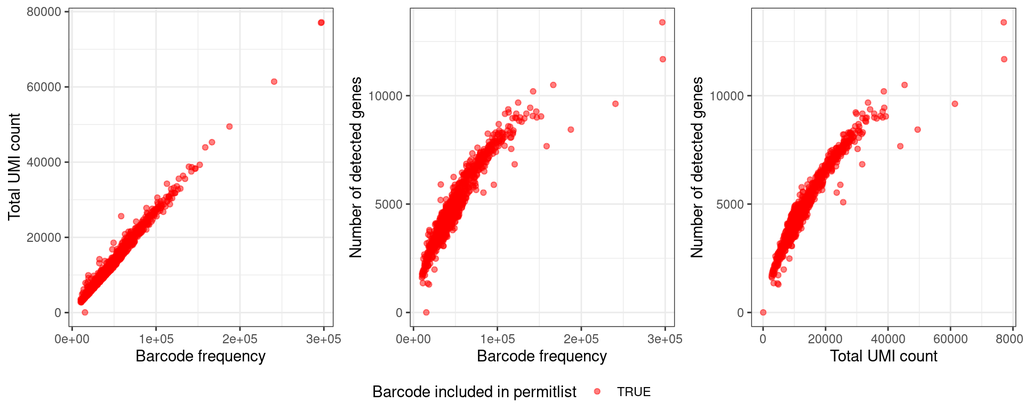

```r
if (!quiet) message("Generating quantification summary plot...")
plotAlevinQuant(alevin$cbTable, colName = "inPermitList",
                cbName = "permitlist",
                firstSelColName = firstSelColName)
```

# Knee plot, number of detected genes

Similarly to the knee plot that was used to select the initial set of cell barcodes, the plot below shows the number of detected genes for each cell barcode included in the permitlist, in decreasing order.

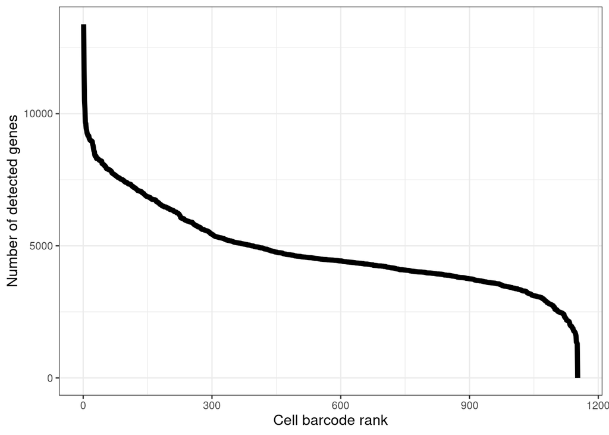

```r
if (!quiet) message("Generating knee plot for nbr genes...")
plotAlevinKneeNbrGenes(alevin$cbTable, firstSelColName = firstSelColName)
```

# Selected summary distributions

The histograms below show the distributions of the deduplication rates (number of deduplicated UMI counts/number of mapped reads) and the mapping rates, across the cells retained in the permitlist.

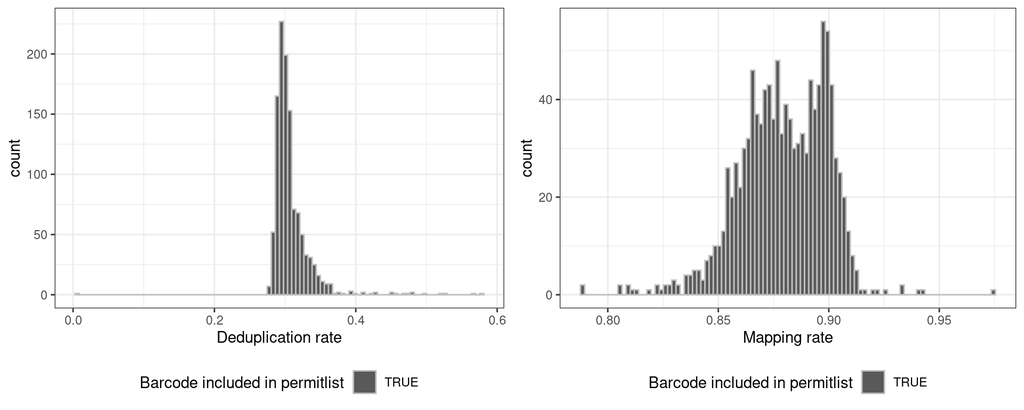

```r
if (!quiet) message("Generating summary distribution plots...")
cowplot::plot_grid(
    plotAlevinHistogram(alevin$cbTable, plotVar = "dedupRate",
                        axisLabel = "Deduplication rate",
                        colName = firstSelColName,
                        cbName = "permitlist",
                        firstSelColName = firstSelColName),
    plotAlevinHistogram(alevin$cbTable, plotVar = "mappingRate",
                        axisLabel = "Mapping rate",
                        colName = firstSelColName,
                        cbName = "permitlist",
                        firstSelColName = firstSelColName),
    nrow = 1
)
```